# A Year in Infectious Disease

Bob Turner

2 January 2018

Reflecting on 2017, did you ever wonder how many cases of scarlet fever (for example) were reported in the UK, and how these varied over time? Then wonder no more! I’ve downloaded 53 weeks of “Notifiable Infectious Disease” data from [gov.uk](https://www.gov.uk/government/collections/notifications-of-infectious-diseases-noids) in a Microsoft Excel workbook, and used **XLConnect** to read this into **R**. I’ve not got all the 2017 data yet, so this goes a couple of weeks back into 2016.

```r
library(XLConnect)
```

```r
wb = loadWorkbook("weekly_statutory_notifable_diseases_tables_week51.xls")
```

I then read the two worksheets I was interested in into data frames, one containing diseases A to K and the other L to Z, and removed the pre-calculated row and column totals.

```r
A_K = readWorksheet(wb, sheet = "Notifications A-K last 52wks", header = TRUE, startRow=8)
A_K<-A_K[-nrow(A_K),] #Remove totals by column
A_K<-A_K[,-ncol(A_K)] #Remove totals by row
L_Z = readWorksheet(wb, sheet = "Notifications L-Z last 52wks", header = TRUE, startRow=8)
L_Z<-L_Z[-nrow(L_Z),] #Remove totals by column
L_Z<-L_Z[,-ncol(L_Z)] #Remove totals by row
head(A_K)
```

|  | Row.Labels | Acute.encephalitis | Acute.infectious.hepatitis | Acute.Meningitis | Botulism | Brucellosis | Cholera | Diphtheria | Enteric.fever..typhoid.or.paratyphoid.fever. | Food.poisoning | Haemolytic.uraemic.syndrome..HUS. | Infectious.bloody.diarrhoea | Invasive.group.A.streptococcal.disease |
| --- | --- | --- | --- | --- | --- | --- | --- | --- | --- | --- | --- | --- | --- |
| 1 | 201651 | NA | 5 | 9 | NA | NA | NA | NA | 2 | 184 | NA | 8 | 7 |
| 2 | 201652 | NA | 5 | 7 | NA | NA | NA | NA | 1 | 121 | NA | 3 | 5 |
| 3 | 201701 | NA | 10 | 13 | NA | NA | NA | NA | 1 | 266 | NA | 5 | 10 |
| 4 | 201702 | NA | 9 | 10 | NA | NA | NA | NA | 3 | 192 | NA | 5 | 6 |
| 5 | 201703 | NA | 3 | 8 | NA | 1 | NA | NA | NA | 170 | NA | 3 | 7 |
| 6 | 201704 | NA | 11 | 6 | NA | NA | NA | 2 | 2 | 187 | NA | 21 | 8 |

You can see that the data is formatted such that each week is a row. The complete data set is split over two data frames. So next, I merged the data frames by week identifier (Row.Labels) such that all rows are included in a single data frame (analogous to a **full outer join** in SQL).

```r
wsndt<-merge(A_K,L_Z,by="Row.Labels",all = TRUE)
```

To make it easier to plot the data, I then restructured the data frame using **melt**. I also gave the columns some more intuitive names, and explicitly set all “NA” values to 0. I’m assuming, here, that “no reported instances” is the same as “no instances”.

Another necessary change was to transform the “week ID” (Row Labels) which are imported as characters into dates. In order to do this, I’ve had to, in effect, assign each weeks worth of data to a single day. This must be considered when doing things with the resulting data frame, but its fine for the kind of plots I’m going to make for now (and for lots of other stuff, too).

```r
library(reshape2)
wsndt<-melt(wsndt, "Row.Labels") #Convert to "long-format", easier to plot
wsndt$Row.Labels<-as.Date(paste(wsndt$Row.Labels,"01"),'%Y%W%w') #We're assigning each datum to the first day of the week
names(wsndt)<-c("Date","Disease","Number.Of.Cases") #Easier to interpret column titles
wsndt[is.na(wsndt)] <- 0 #We're going to assume that NA==No Cases Reported==0 Cases
head(wsndt)
```

|  | Date | Disease | Number.Of.Cases |
| --- | --- | --- | --- |
| 1 | 2016-12-18 | Acute.encephalitis | 0 |
| 2 | 2016-12-25 | Acute.encephalitis | 0 |
| 3 | 2017-01-01 | Acute.encephalitis | 0 |
| 4 | 2017-01-08 | Acute.encephalitis | 0 |
| 5 | 2017-01-15 | Acute.encephalitis | 0 |
| 6 | 2017-01-22 | Acute.encephalitis | 0 |

I can now plot the number reports of each disease by week over the 53 weeks I have data for, and we can begin to form an interpretation of what’s been going on which might form the basis for more sophisticated analysis.

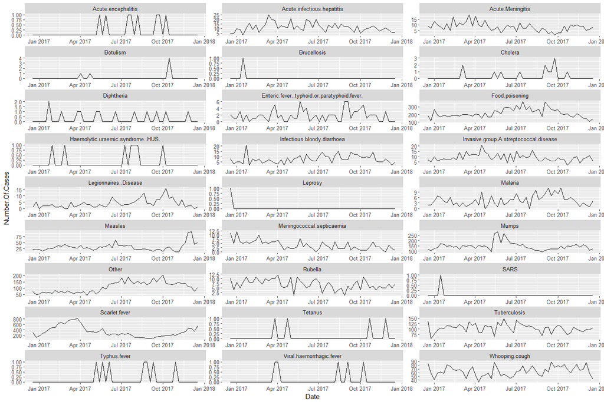

```r
library(ggplot2)
ggplot(wsndt, aes(x=Date, y=Number.Of.Cases, group=1))+
  geom_line()+
  facet_wrap(~Disease, ncol = 3, scales = "free")+
  theme(text = element_text(size=12))
```

Be aware, these are all on different scales!

Finally, I’m going to save my data frame for use with a [Shiny Web App](https://bobturner.shinyapps.io/Year_in_Disease_Shiny/).

```r
saveRDS(wsndt,"wsndt.Rda")
```

See my [website](https://sites.google.com/view/robert-turner) for more examples. Contact me on bob dot turner dot uk at gmail dot com with comments or questions.

Contains public sector information licensed under the Open Government Licence v3.0.